# Data Analysis Carsales data

# DataFrame Object

DataFrame is the a main object in pandas.It is used to represent data with rows and columns(tabular or excel spreadshee like data

```python
car.shape
```

```
(157, 17)
```

### Statistics of your dataframe

- we can see the statistics of our dataframe by calling describe() function
- It will print count of the columns,mean,SD,min,max etc..

```python
car.describe()
```

|  | Sales in thousands | x_4_year | Price in thousands | Engine size | Horsepower | Wheelbase | Width | Length | Curb weight | Fuel capacity | Fuel efficiency | Unnamed: 15 | XX |
| --- | --- | --- | --- | --- | --- | --- | --- | --- | --- | --- | --- | --- | --- |
| count | 157.000000 | 121.000000 | 155.000000 | 156.000000 | 156.000000 | 156.000000 | 156.000000 | 156.000000 | 155.000000 | 156.000000 | 154.000000 | 0.0 | 121.000000 |
| mean | 52.998076 | 18.072975 | 27.390755 | 3.060897 | 185.948718 | 107.487179 | 71.150000 | 187.343590 | 3.378026 | 17.951923 | 23.844156 | NaN | 18.072975 |
| std | 68.029422 | 11.453384 | 14.351653 | 1.044653 | 56.700321 | 7.641303 | 3.451872 | 13.431754 | 0.630502 | 3.887921 | 4.282706 | NaN | 11.453384 |
| min | 0.110000 | 5.160000 | 9.235000 | 1.000000 | 55.000000 | 92.600000 | 62.600000 | 149.400000 | 1.895000 | 10.300000 | 15.000000 | NaN | 5.160000 |
| 25% | 14.114000 | 11.260000 | 18.017500 | 2.300000 | 149.500000 | 103.000000 | 68.400000 | 177.575000 | 2.971000 | 15.800000 | 21.000000 | NaN | 11.260000 |
| 50% | 29.450000 | 14.180000 | 22.799000 | 3.000000 | 177.500000 | 107.000000 | 70.550000 | 187.900000 | 3.342000 | 17.200000 | 24.000000 | NaN | 14.180000 |
| 75% | 67.956000 | 19.875000 | 31.947500 | 3.575000 | 215.000000 | 112.200000 | 73.425000 | 196.125000 | 3.799500 | 19.575000 | 26.000000 | NaN | 19.875000 |
| max | 540.561000 | 67.550000 | 85.500000 | 8.000000 | 450.000000 | 138.700000 | 79.900000 | 224.500000 | 5.572000 | 32.000000 | 45.000000 | NaN | 67.550000 |

```python
#To get dataframe where temperature is greater than 9
d1=car[car['Fuel efficiency']>car['Fuel efficiency'].mean()]
d1
```

|  | Manufacturer | Model | Sales in thousands | x_4_year | Vehicle type | Price in thousands | Engine size | Horsepower | Wheelbase | Width | Length | Curb weight | Fuel capacity | Fuel efficiency | Latest Launch | Unnamed: 15 | XX |
| --- | --- | --- | --- | --- | --- | --- | --- | --- | --- | --- | --- | --- | --- | --- | --- | --- | --- |
| 0 | Acura | Integra | 16.919 | 16.360 | Passenger | 21.50 | 1.8 | 140.0 | 101.2 | 67.3 | 172.4 | 2.639 | 13.2 | 28.0 | 2-Feb-14 | NaN | 16.360 |
| 1 | Acura | TL | 39.384 | 19.875 | Passenger | 28.40 | 3.2 | 225.0 | 108.1 | 70.3 | 192.9 | 3.517 | 17.2 | 25.0 | 6-Mar-15 | NaN | 19.875 |
| 2 | Acura | CL | 14.114 | 18.225 | Passenger | NaN | 3.2 | 225.0 | 106.9 | 70.6 | 192.0 | 3.470 | 17.2 | 26.0 | 1-Apr-14 | NaN | 18.225 |
| 4 | Audi | A4 | 20.397 | 22.255 | Passenger | 23.99 | 1.8 | 150.0 | 102.6 | 68.2 | 178.0 | 2.998 | 16.4 | 27.0 | 10-Aug-15 | NaN | 22.255 |
| 7 | BMW | 323i | 19.747 | NaN | Passenger | 26.99 | 2.5 | 170.0 | 107.3 | 68.4 | 176.0 | 3.179 | 16.6 | 26.0 | 28-Jun-15 | NaN | NaN |
| ... | ... | ... | ... | ... | ... | ... | ... | ... | ... | ... | ... | ... | ... | ... | ... | ... | ... |
| 151 | Volvo | S40 | 16.957 | NaN | Passenger | 23.40 | 1.9 | 160.0 | 100.5 | 67.6 | 176.6 | 2.998 | 15.8 | 25.0 | 18-Feb-15 | NaN | NaN |
| 152 | Volvo | V40 | 3.545 | NaN | Passenger | 24.40 | 1.9 | 160.0 | 100.5 | 67.6 | 176.6 | 3.042 | 15.8 | 25.0 | 21-Sep-15 | NaN | NaN |
| 153 | Volvo | S70 | 15.245 | NaN | Passenger | 27.50 | 2.4 | 168.0 | 104.9 | 69.3 | 185.9 | 3.208 | 17.9 | 25.0 | 24-Nov-14 | NaN | NaN |
| 154 | Volvo | V70 | 17.531 | NaN | Passenger | 28.80 | 2.4 | 168.0 | 104.9 | 69.3 | 186.2 | 3.259 | 17.9 | 25.0 | 25-Jun-15 | NaN | NaN |
| 156 | Volvo | S80 | 18.969 | NaN | Passenger | 36.00 | 2.9 | 201.0 | 109.9 | 72.1 | 189.8 | 3.600 | 21.1 | 24.0 | 14-Nov-15 | NaN | NaN |

85 rows × 17 columns

```python
car.columns
```

```
Index(['Manufacturer', 'Model', 'Sales in thousands', 'x_4_year',
       'Vehicle type', 'Price in thousands', 'Engine size', 'Horsepower',
       'Wheelbase', 'Width', 'Length', 'Curb weight', 'Fuel capacity',
       'Fuel efficiency', 'Latest Launch', 'Unnamed: 15', 'XX'],
      dtype='object')
```

### Cleaning data

```python
car.isnull().sum()
```

```
Manufacturer            0
Model                   0
Sales in thousands      0
x_4_year               36
Vehicle type            0
Price in thousands      2
Engine size             1
Horsepower              1
Wheelbase               1
Width                   1
Length                  1
Curb weight             2
Fuel capacity           1
Fuel efficiency         3
Latest Launch           0
Unnamed: 15           157
XX                     36
dtype: int64
```

```python
#Remove unnecessary columns from the data, depending on your own understandings
car.drop(["Unnamed: 15","XX"],axis=1,inplace=True)
```

```python
car.isnull().sum()
```

```
Manufacturer           0
Model                  0
Sales in thousands     0
x_4_year              36
Vehicle type           0
Price in thousands     2
Engine size            1
Horsepower             1
Wheelbase              1
Width                  1
Length                 1
Curb weight            2
Fuel capacity          1
Fuel efficiency        3
Latest Launch          0
dtype: int64
```

### Treat all the missing values with mean/median or most occuring observation

```python
car["x_4_year"].fillna(value=car["x_4_year"].mean(),inplace=True)
car["Price in thousands"].fillna(value=car["Price in thousands"].mean(),inplace=True)
car["Curb weight"].fillna(value=car["Curb weight"].mean(),inplace=True)
car["Engine size"].fillna(value=car["Engine size"].mean(),inplace=True)
car["Horsepower"].fillna(value=car["Horsepower"].mean(),inplace=True)
car["Wheelbase"].fillna(value=car["Wheelbase"].mean(),inplace=True)
car["Width"].fillna(value=car["Width"].mean(),inplace=True)
car["Length"].fillna(value=car["Length"].mean(),inplace=True)
car["Fuel efficiency"].fillna(value=car["Fuel efficiency"].mean(),inplace=True)
car["Fuel capacity"].fillna(value=car["Fuel capacity"].mean(),inplace=True)
car
```

|  | Manufacturer | Model | Sales in thousands | x_4_year | Vehicle type | Price in thousands | Engine size | Horsepower | Wheelbase | Width | Length | Curb weight | Fuel capacity | Fuel efficiency | Latest Launch |
| --- | --- | --- | --- | --- | --- | --- | --- | --- | --- | --- | --- | --- | --- | --- | --- |
| 0 | Acura | Integra | 16.919 | 16.360000 | Passenger | 21.500000 | 1.8 | 140.0 | 101.2 | 67.3 | 172.4 | 2.639 | 13.2 | 28.0 | 2-Feb-14 |
| 1 | Acura | TL | 39.384 | 19.875000 | Passenger | 28.400000 | 3.2 | 225.0 | 108.1 | 70.3 | 192.9 | 3.517 | 17.2 | 25.0 | 6-Mar-15 |
| 2 | Acura | CL | 14.114 | 18.225000 | Passenger | 27.390755 | 3.2 | 225.0 | 106.9 | 70.6 | 192.0 | 3.470 | 17.2 | 26.0 | 1-Apr-14 |
| 3 | Acura | RL | 8.588 | 29.725000 | Passenger | 42.000000 | 3.5 | 210.0 | 114.6 | 71.4 | 196.6 | 3.850 | 18.0 | 22.0 | 3-Oct-15 |
| 4 | Audi | A4 | 20.397 | 22.255000 | Passenger | 23.990000 | 1.8 | 150.0 | 102.6 | 68.2 | 178.0 | 2.998 | 16.4 | 27.0 | 10-Aug-15 |
| ... | ... | ... | ... | ... | ... | ... | ... | ... | ... | ... | ... | ... | ... | ... | ... |
| 152 | Volvo | V40 | 3.545 | 18.072975 | Passenger | 24.400000 | 1.9 | 160.0 | 100.5 | 67.6 | 176.6 | 3.042 | 15.8 | 25.0 | 21-Sep-15 |
| 153 | Volvo | S70 | 15.245 | 18.072975 | Passenger | 27.500000 | 2.4 | 168.0 | 104.9 | 69.3 | 185.9 | 3.208 | 17.9 | 25.0 | 24-Nov-14 |
| 154 | Volvo | V70 | 17.531 | 18.072975 | Passenger | 28.800000 | 2.4 | 168.0 | 104.9 | 69.3 | 186.2 | 3.259 | 17.9 | 25.0 | 25-Jun-15 |
| 155 | Volvo | C70 | 3.493 | 18.072975 | Passenger | 45.500000 | 2.3 | 236.0 | 104.9 | 71.5 | 185.7 | 3.601 | 18.5 | 23.0 | 26-Apr-15 |
| 156 | Volvo | S80 | 18.969 | 18.072975 | Passenger | 36.000000 | 2.9 | 201.0 | 109.9 | 72.1 | 189.8 | 3.600 | 21.1 | 24.0 | 14-Nov-15 |

157 rows × 15 columns

```python
car.isnull().sum()
```

```
Manufacturer          0
Model                 0
Sales in thousands    0
x_4_year              0
Vehicle type          0
Price in thousands    0
Engine size           0
Horsepower            0
Wheelbase             0
Width                 0
Length                0
Curb weight           0
Fuel capacity         0
Fuel efficiency       0
Latest Launch         0
dtype: int64
```

```python
car["Manufacturer"]=car["Manufacturer"].str.strip()
car["Manufacturer"].values
```

```
array(['Acura', 'Acura', 'Acura', 'Acura', 'Audi', 'Audi', 'Audi', 'BMW',
       'BMW', 'BMW', 'Buick', 'Buick', 'Buick', 'Buick', 'Cadillac',
       'Cadillac', 'Cadillac', 'Cadillac', 'Cadillac', 'Chevrolet',
       'Chevrolet', 'Chevrolet', 'Chevrolet', 'Chevrolet', 'Chevrolet',
       'Chevrolet', 'Chevrolet', 'Chevrolet', 'Chrysler', 'Chrysler',
       'Chrysler', 'Chrysler', 'Chrysler', 'Chrysler', 'Chrysler',
       'Dodge', 'Dodge', 'Dodge', 'Dodge', 'Dodge', 'Dodge', 'Dodge',
       'Dodge', 'Dodge', 'Dodge', 'Dodge', 'Ford', 'Ford', 'Ford', 'Ford',
       'Ford', 'Ford', 'Ford', 'Ford', 'Ford', 'Ford', 'Ford', 'Honda',
       'Honda', 'Honda', 'Honda', 'Honda', 'Hyundai', 'Hyundai',
       'Hyundai', 'Infiniti', 'Jaguar', 'Jeep', 'Jeep', 'Jeep', 'Lexus',
       'Lexus', 'Lexus', 'Lexus', 'Lexus', 'Lexus', 'Lincoln', 'Lincoln',
       'Lincoln', 'Mitsubishi', 'Mitsubishi', 'Mitsubishi', 'Mitsubishi',
       'Mitsubishi', 'Mitsubishi', 'Mitsubishi', 'Mercury', 'Mercury',
       'Mercury', 'Mercury', 'Mercury', 'Mercury', 'Mercedes-Benz',
       'Mercedes-Benz', 'Mercedes-Benz', 'Mercedes-Benz', 'Mercedes-Benz',
       'Mercedes-Benz', 'Mercedes-Benz', 'Mercedes-Benz', 'Mercedes-Benz',
       'Nissan', 'Nissan', 'Nissan', 'Nissan', 'Nissan', 'Nissan',
       'Nissan', 'Oldsmobile', 'Oldsmobile', 'Oldsmobile', 'Oldsmobile',
       'Oldsmobile', 'Oldsmobile', 'Plymouth', 'Plymouth', 'Plymouth',
       'Plymouth', 'Pontiac', 'Pontiac', 'Pontiac', 'Pontiac', 'Pontiac',
       'Pontiac', 'Porsche', 'Porsche', 'Porsche', 'Saab', 'Saab',
       'Saturn', 'Saturn', 'Saturn', 'Saturn', 'Saturn', 'Subaru',
       'Subaru', 'Toyota', 'Toyota', 'Toyota', 'Toyota', 'Toyota',
       'Toyota', 'Toyota', 'Toyota', 'Toyota', 'Volkswagen', 'Volkswagen',
       'Volkswagen', 'Volkswagen', 'Volkswagen', 'Volkswagen', 'Volvo',
       'Volvo', 'Volvo', 'Volvo', 'Volvo', 'Volvo'], dtype=object)
```

### Fetch the name of the model and company's name which have lowest sales.

```python
car.loc[:,["Manufacturer","Model","Sales in thousands"]].sort_values("Sales in thousands",ascending=True).head(2)
```

|  | Manufacturer | Model | Sales in thousands |
| --- | --- | --- | --- |
| 83 | Mitsubishi | 3000GT | 0.110 |
| 39 | Dodge | Viper | 0.916 |

### Fetch the name of the model and company's name which have lowest sales with respect to Vehicle Type Passenger

```python
car.groupby("Vehicle type").min()
```

| Vehicle type | Manufacturer | Model | Sales in thousands | x_4_year | Price in thousands | Engine size | Horsepower | Wheelbase | Width | Length | Curb weight | Fuel capacity | Fuel efficiency | Latest Launch |
| --- | --- | --- | --- | --- | --- | --- | --- | --- | --- | --- | --- | --- | --- | --- |
| Car | Cadillac | 4Runner | 9.126 | 7.85 | 11.528 | 2.0 | 119.0 | 93.4 | 66.5 | 152.0 | 2.580 | 15.1 | 15.0 | 1-Apr-14 |
| Passenger | Acura | 3-Sep | 0.110 | 5.16 | 9.235 | 1.0 | 55.0 | 92.6 | 62.6 | 149.4 | 1.895 | 10.3 | 16.0 | 1-Apr-14 |

### Fetch the name of the model and company's name which have Highest sales with respect to Engine Size > 6

```python
x1=car[car["Engine size"]>6].sort_values("Sales in thousands",ascending=False)
x1.loc[:,["Manufacturer","Model","Sales in thousands","Engine size"]]
```

|  | Manufacturer | Model | Sales in thousands | Engine size |
| --- | --- | --- | --- | --- |
| 39 | Dodge | Viper | 0.916 | 8.0 |

### Fetch the company name who has got lowest mileage with respect to Vehicle Type as Passengers.

```python
x2=car[car["Vehicle type"]=="Passenger"].sort_values("Fuel efficiency",ascending=True)
x2.loc[:,["Manufacturer","Model","Vehicle type","Fuel efficiency"]].head(2)
```

|  | Manufacturer | Model | Vehicle type | Fuel efficiency |
| --- | --- | --- | --- | --- |
| 39 | Dodge | Viper | Passenger | 16.0 |
| 95 | Mercedes-Benz | SL-Class | Passenger | 20.0 |

### Fetch the company name who has got least price and maximum number of sales figures.

```python
x3=car.loc[:,["Manufacturer","Model","Sales in thousands","Price in thousands"]].sort_values("Sales in thousands",ascending=False)

x3["ratio of sales/price"]=car["Sales in thousands"]/car["Price in thousands"]
x3.sort_values("ratio of sales/price",ascending=False).head(2)
```

|  | Manufacturer | Model | Sales in thousands | Price in thousands | ratio of sales/price |
| --- | --- | --- | --- | --- | --- |
| 56 | Ford | F-Series | 540.561 | 26.935 | 20.069092 |
| 55 | Ford | Ranger | 220.650 | 12.050 | 18.311203 |

### Fetch the model who has got maximum number of Horsepower

```python
x4=car.loc[:,["Model","Horsepower"]].sort_values("Horsepower",ascending=False)
x4.head(2)
```

|  | Model | Horsepower |
| --- | --- | --- |
| 39 | Viper | 450.0 |
| 24 | Corvette | 345.0 |

### Fetch the model and company name wo has got minimum mileage with highest sales figures.

```python
x5=car.loc[:,["Manufacturer","Model","Sales in thousands","Fuel efficiency"]].sort_values("Fuel efficiency",ascending=True)
x5.head(2)
```

|  | Manufacturer | Model | Sales in thousands | Fuel efficiency |
| --- | --- | --- | --- | --- |
| 78 | Lincoln | Navigator | 22.925 | 15.0 |
| 144 | Toyota | Land Cruiser | 9.835 | 15.0 |

- Fetch the model and company name where the wheel base is maximum with Vehicle type as Car

```python
x6=car[car["Vehicle type"]=="Car"].sort_values("Wheelbase",ascending=False)
x6.loc[:,["Manufacturer","Model","Vehicle type","Wheelbase"]].head(5)
```

|  | Manufacturer | Model | Vehicle type | Wheelbase |
| --- | --- | --- | --- | --- |
| 40 | Dodge | Ram Pickup | Car | 138.7 |
| 56 | Ford | F-Series | Car | 138.5 |
| 43 | Dodge | Dakota | Car | 131.0 |
| 42 | Dodge | Ram Van | Car | 127.2 |
| 53 | Ford | Windstar | Car | 120.7 |

### Fetch the model and company name where the wheel base is minimum with Vehicle type as Passengers

```python
x7=car[car["Vehicle type"]=="Passenger"].sort_values("Wheelbase",ascending=True)
x7.loc[:,["Manufacturer","Model","Vehicle type","Wheelbase"]].head(5)
```

|  | Manufacturer | Model | Vehicle type | Wheelbase |
| --- | --- | --- | --- | --- |
| 126 | Porsche | Carrera Cabriolet | Passenger | 92.6 |
| 125 | Porsche | Carrera Coupe | Passenger | 92.6 |
| 26 | Chevrolet | Metro | Passenger | 93.1 |
| 96 | Mercedes-Benz | SLK | Passenger | 94.5 |
| 97 | Mercedes-Benz | SLK230 | Passenger | 94.5 |

### Fetch the model and company name where the curb weight is minimum with minimum mileage

```python
x8=car.loc[:,["Manufacturer","Model","Sales in thousands","Curb weight","Fuel efficiency"]].sort_values("Curb weight",ascending=True)
x8.head()
```

|  | Manufacturer | Model | Sales in thousands | Curb weight | Fuel efficiency |
| --- | --- | --- | --- | --- | --- |
| 26 | Chevrolet | Metro | 21.855 | 1.895 | 45.0 |
| 62 | Hyundai | Accent | 41.184 | 2.240 | 31.0 |
| 79 | Mitsubishi | Mirage | 26.232 | 2.250 | 30.0 |
| 129 | Saturn | SL | 80.620 | 2.332 | 33.0 |
| 57 | Honda | Civic | 199.685 | 2.339 | 32.0 |

### Matplotlib -scatter plot

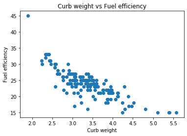

```python
plt.scatter(car["Curb weight"],car["Fuel efficiency"])
plt.xlabel("Curb weight")
plt.ylabel("Fuel efficiency")
plt.title("Curb weight vs Fuel efficiency")
```

### Change the name of column x_4_year to 4_Year_Resale_Value

```python
car.rename(columns={ "x_4_year":"4_Year_Resale_Value"},inplace=True)
car.head()
```

|  | Manufacturer | Model | Sales in thousands | 4_Year_Resale_Value | Vehicle type | Price in thousands | Engine size | Horsepower | Wheelbase | Width | Length | Curb weight | Fuel capacity | Fuel efficiency | Latest Launch |
| --- | --- | --- | --- | --- | --- | --- | --- | --- | --- | --- | --- | --- | --- | --- | --- |
| 0 | Acura | Integra | 16.919 | 16.360 | Passenger | 21.500000 | 1.8 | 140.0 | 101.2 | 67.3 | 172.4 | 2.639 | 13.2 | 28.0 | 2-Feb-14 |
| 1 | Acura | TL | 39.384 | 19.875 | Passenger | 28.400000 | 3.2 | 225.0 | 108.1 | 70.3 | 192.9 | 3.517 | 17.2 | 25.0 | 6-Mar-15 |
| 2 | Acura | CL | 14.114 | 18.225 | Passenger | 27.390755 | 3.2 | 225.0 | 106.9 | 70.6 | 192.0 | 3.470 | 17.2 | 26.0 | 1-Apr-14 |
| 3 | Acura | RL | 8.588 | 29.725 | Passenger | 42.000000 | 3.5 | 210.0 | 114.6 | 71.4 | 196.6 | 3.850 | 18.0 | 22.0 | 3-Oct-15 |
| 4 | Audi | A4 | 20.397 | 22.255 | Passenger | 23.990000 | 1.8 | 150.0 | 102.6 | 68.2 | 178.0 | 2.998 | 16.4 | 27.0 | 10-Aug-15 |

### Fetch the model and company name whose sales and Resale Value is Highest

```python
car.groupby("Manufacturer").max().sort_values("Sales in thousands",ascending=False).head().loc[:,["Model","Sales in thousands","4_Year_Resale_Value"]]
```

| Manufacturer | Model | Sales in thousands | 4_Year_Resale_Value |
| --- | --- | --- | --- |
| Ford | Windstar | 540.561 | 23.575 |
| Toyota | Tacoma | 247.994 | 34.080 |
| Honda | Passport | 230.902 | 19.490 |
| Dodge | Viper | 227.061 | 58.470 |
| Jeep | Wrangler | 157.040 | 18.810 |

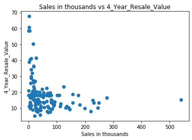

```python
plt.scatter(car["Sales in thousands"],car["4_Year_Resale_Value"])
plt.xlabel("Sales in thousands")
plt.ylabel("4_Year_Resale_Value")
plt.title("Sales in thousands vs 4_Year_Resale_Value")
```

### Fetch the model and company name whose sales, Mileage and Resale Value is Highest but Price is lowest

```python
car.groupby("Manufacturer").min().sort_values("Price in thousands",ascending=True).head(5).loc[:,["Model","Sales in thousands","Price in thousands", "Fuel capacity","4_Year_Resale_Value"]]
```

| Manufacturer | Model | Sales in thousands | Price in thousands | Fuel capacity | 4_Year_Resale_Value |
| --- | --- | --- | --- | --- | --- |
| Chevrolet | Camaro | 17.947 | 9.235 | 10.3 | 5.160 |
| Hyundai | Accent | 29.450 | 9.699 | 11.9 | 5.860 |
| Saturn | LS | 5.223 | 10.685 | 12.1 | 9.200 |
| Toyota | 4Runner | 9.835 | 11.528 | 13.2 | 9.575 |
| Ford | Contour | 35.068 | 12.050 | 12.7 | 7.425 |

### Fetch the model and company name whole resale value is lowest but sale is highest.

```python
car.groupby("Manufacturer").min().sort_values("4_Year_Resale_Value",ascending=True).head(3).loc[:,["Model","Sales in thousands","Price in thousands", "Fuel capacity","4_Year_Resale_Value"]]
```

| Manufacturer | Model | Sales in thousands | Price in thousands | Fuel capacity | 4_Year_Resale_Value |
| --- | --- | --- | --- | --- | --- |
| Chevrolet | Camaro | 17.947 | 9.235 | 10.3 | 5.160 |
| Hyundai | Accent | 29.450 | 9.699 | 11.9 | 5.860 |
| Ford | Contour | 35.068 | 12.050 | 12.7 | 7.425 |

Matplotlib is the "grandfather" library of data visualization with Python. It was created by John Hunter. He created it to try to replicate MatLab's (another programming language) plotting capabilities in Python. So if you happen to be familiar with matlab, matplotlib will feel natural to you.

It is an excellent 2D and 3D graphics library for generating scientific figures.

Some of the major Pros of Matplotlib are:

- Generally easy to get started for simple plots
- Support for custom labels and texts
- Great control of every element in a figure
- High-quality output in many formats
- Very customizable in general

# Distplot

```python
car['Sales in thousands'].mean()
```

```
52.99807643312102
```

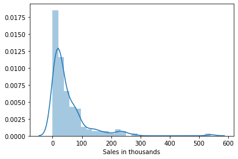

```python
sns.distplot(car['Sales in thousands']);
```

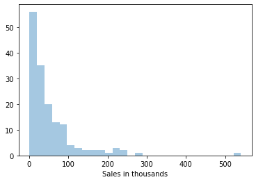

```python
sns.distplot(car['Sales in thousands'],kde=False);
```

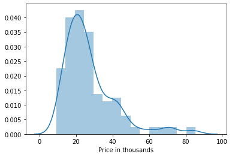

```python
sns.distplot(car['Price in thousands']);
```

```python
car['Fuel efficiency'].mean()
```

```
23.844155844155846
```

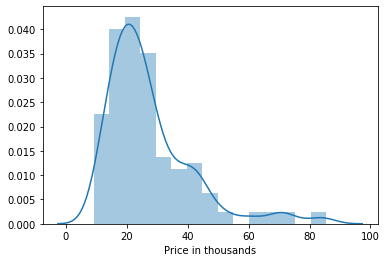

```python
sns.distplot(car['Price in thousands'],kde=True);
```

### Jointplot

Below we can observe the following points from Jointplot graph:

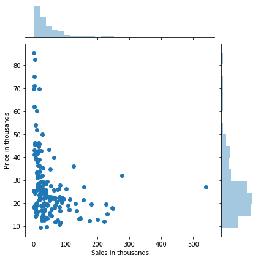

```python
sns.jointplot(x='Sales in thousands',y='Price in thousands',data=car,kind='scatter');
```

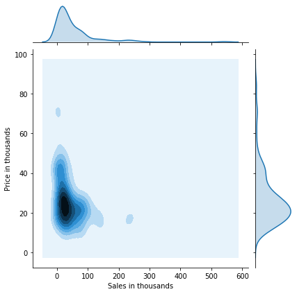

```python
sns.jointplot(x='Sales in thousands',y='Price in thousands',data=car,kind='kde');
```

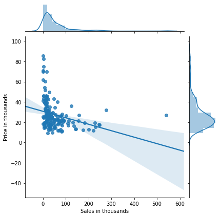

```python
sns.jointplot(x='Sales in thousands',y='Price in thousands',data=car,kind='reg');
```

### PairPlot

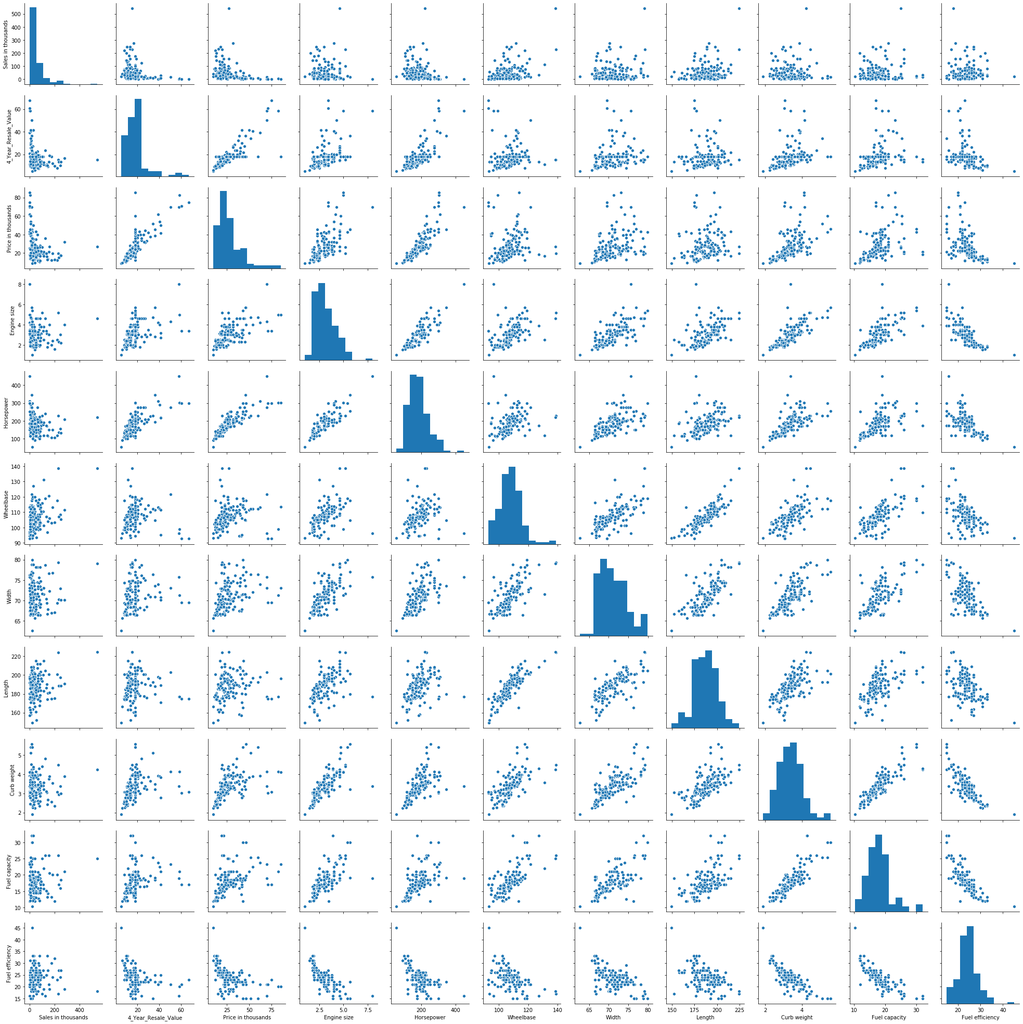

```python
sns.pairplot(car);
```

## Kdeplots

Kdeplots just only displays the normal distribution of the variables. we could also combineKdeplot with rugplot

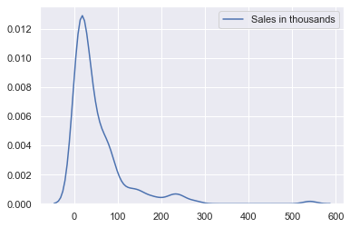

```python
sns.set()#background grid
sns.kdeplot(car['Sales in thousands'])
```

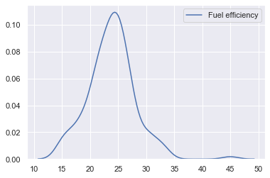

```python
sns.set()
sns.kdeplot(car['Fuel efficiency'])
```

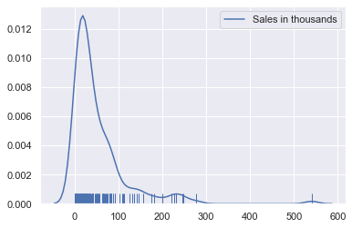

```python
sns.set()
sns.kdeplot(car['Sales in thousands']);
sns.rugplot(car['Sales in thousands']);
```

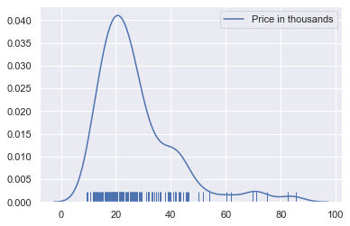

```python
sns.set()
sns.kdeplot(car['Price in thousands']);
sns.rugplot(car['Price in thousands']);
```

### A heatmap of pivot table with cars data where the pivot table will be representing at which year which company generates what sales /price figures

```python
car["Time"]=pd.to_datetime(car["Latest Launch"])
```

```python
car["year"]=car['Time'].dt.year
car["month"]=car['Time'].dt.month_name()
car
```

|  | Manufacturer | Model | Sales in thousands | 4_Year_Resale_Value | Vehicle type | Price in thousands | Engine size | Horsepower | Wheelbase | Width | Length | Curb weight | Fuel capacity | Fuel efficiency | Latest Launch | Time | year | month |
| --- | --- | --- | --- | --- | --- | --- | --- | --- | --- | --- | --- | --- | --- | --- | --- | --- | --- | --- |
| 0 | Acura | Integra | 16.919 | 16.360000 | Passenger | 21.500000 | 1.8 | 140.0 | 101.2 | 67.3 | 172.4 | 2.639 | 13.2 | 28.0 | 2-Feb-14 | 2014-02-02 | 2014 | February |
| 1 | Acura | TL | 39.384 | 19.875000 | Passenger | 28.400000 | 3.2 | 225.0 | 108.1 | 70.3 | 192.9 | 3.517 | 17.2 | 25.0 | 6-Mar-15 | 2015-03-06 | 2015 | March |
| 2 | Acura | CL | 14.114 | 18.225000 | Passenger | 27.390755 | 3.2 | 225.0 | 106.9 | 70.6 | 192.0 | 3.470 | 17.2 | 26.0 | 1-Apr-14 | 2014-04-01 | 2014 | April |
| 3 | Acura | RL | 8.588 | 29.725000 | Passenger | 42.000000 | 3.5 | 210.0 | 114.6 | 71.4 | 196.6 | 3.850 | 18.0 | 22.0 | 3-Oct-15 | 2015-10-03 | 2015 | October |
| 4 | Audi | A4 | 20.397 | 22.255000 | Passenger | 23.990000 | 1.8 | 150.0 | 102.6 | 68.2 | 178.0 | 2.998 | 16.4 | 27.0 | 10-Aug-15 | 2015-08-10 | 2015 | August |
| ... | ... | ... | ... | ... | ... | ... | ... | ... | ... | ... | ... | ... | ... | ... | ... | ... | ... | ... |
| 152 | Volvo | V40 | 3.545 | 18.072975 | Passenger | 24.400000 | 1.9 | 160.0 | 100.5 | 67.6 | 176.6 | 3.042 | 15.8 | 25.0 | 21-Sep-15 | 2015-09-21 | 2015 | September |
| 153 | Volvo | S70 | 15.245 | 18.072975 | Passenger | 27.500000 | 2.4 | 168.0 | 104.9 | 69.3 | 185.9 | 3.208 | 17.9 | 25.0 | 24-Nov-14 | 2014-11-24 | 2014 | November |
| 154 | Volvo | V70 | 17.531 | 18.072975 | Passenger | 28.800000 | 2.4 | 168.0 | 104.9 | 69.3 | 186.2 | 3.259 | 17.9 | 25.0 | 25-Jun-15 | 2015-06-25 | 2015 | June |
| 155 | Volvo | C70 | 3.493 | 18.072975 | Passenger | 45.500000 | 2.3 | 236.0 | 104.9 | 71.5 | 185.7 | 3.601 | 18.5 | 23.0 | 26-Apr-15 | 2015-04-26 | 2015 | April |
| 156 | Volvo | S80 | 18.969 | 18.072975 | Passenger | 36.000000 | 2.9 | 201.0 | 109.9 | 72.1 | 189.8 | 3.600 | 21.1 | 24.0 | 14-Nov-15 | 2015-11-14 | 2015 | November |

157 rows × 18 columns

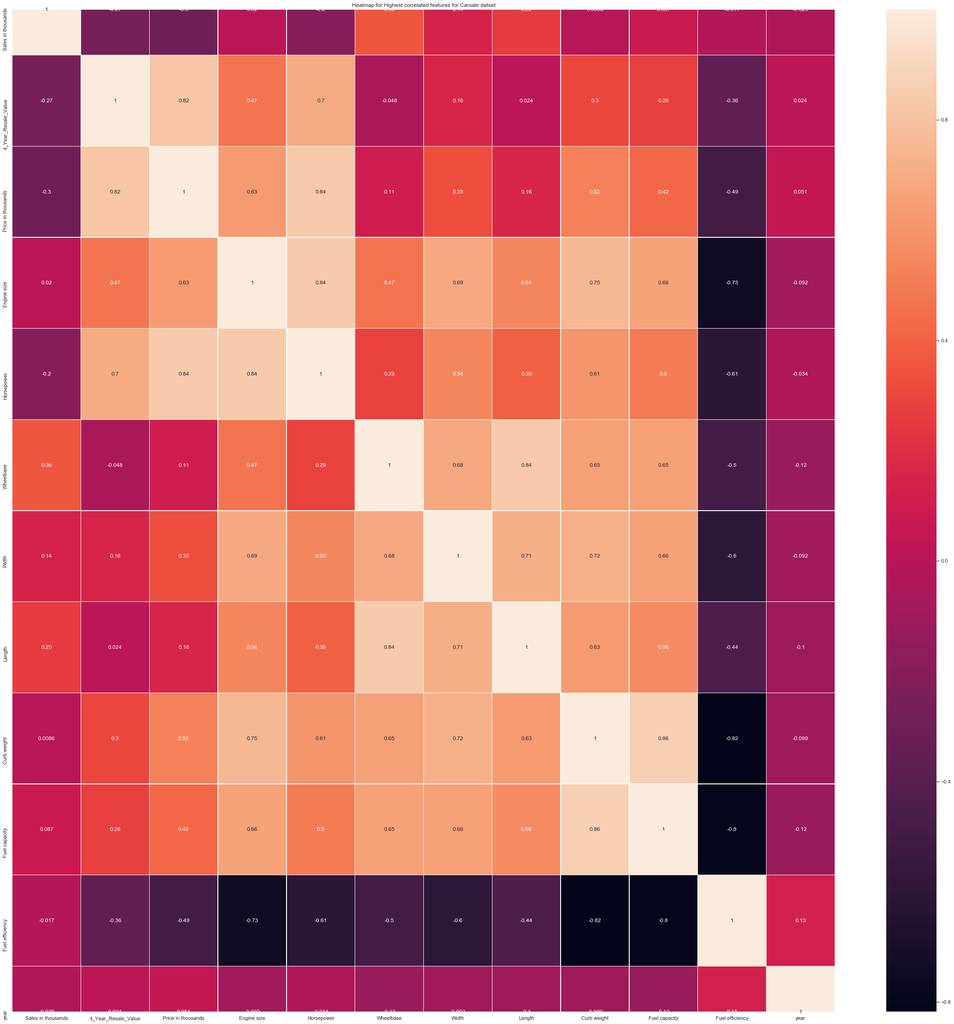

```python
plt.figure(figsize=(40,40))
sns.heatmap(car.corr(),annot=True, linewidths=.5)
plt.title("Heatmap for Highest correlated features for Carsale datset")
```

```python
carsales=car.pivot_table(values='Sales in thousands',index='Manufacturer',columns='year')
carsales
```

| year Manufacturer | 2008 | 2009 | 2014 | 2015 |
| --- | --- | --- | --- | --- |
| Acura | NaN | NaN | 15.516500 | 23.986000 |
| Audi | NaN | NaN | 1.380000 | 19.588500 |
| BMW | NaN | NaN | 9.231000 | 18.637000 |
| Buick | NaN | NaN | 27.851000 | 71.389333 |
| Cadillac | NaN | NaN | 39.257000 | 11.221333 |
| Chevrolet | NaN | NaN | 58.309333 | 63.239500 |
| Chrysler | NaN | NaN | 20.790000 | 39.520333 |
| Dodge | NaN | NaN | 78.158500 | 88.239600 |
| Ford | NaN | NaN | 190.379667 | 154.609000 |
| Honda | NaN | NaN | 98.247250 | 199.685000 |
| Hyundai | NaN | NaN | 35.317000 | 66.692000 |
| Infiniti | NaN | NaN | 23.713000 | NaN |
| Jaguar | NaN | NaN | 15.467000 | NaN |
| Jeep | NaN | NaN | 68.056500 | 157.040000 |
| Lexus | NaN | NaN | 17.807167 | NaN |
| Lincoln | NaN | NaN | 28.544667 | NaN |
| Mercedes-Benz | NaN | NaN | NaN | 13.013889 |
| Mercury | 27.609 | 20.380 | 47.502500 | NaN |
| Mitsubishi | NaN | NaN | 25.842143 | NaN |
| Nissan | NaN | NaN | NaN | 57.090714 |
| Oldsmobile | NaN | 80.255 | NaN | 19.746800 |
| Plymouth | NaN | NaN | 1.872000 | 20.709667 |
| Pontiac | NaN | NaN | 66.917800 | 35.945000 |
| Porsche | NaN | NaN | 5.131000 | 1.866000 |
| Saab | NaN | NaN | 9.191000 | 12.115000 |
| Saturn | NaN | NaN | 65.304500 | 12.747000 |
| Subaru | NaN | NaN | 33.028000 | 47.107000 |
| Toyota | NaN | NaN | 49.194000 | 91.688143 |
| Volkswagen | NaN | NaN | 51.102000 | 31.622000 |
| Volvo | NaN | NaN | 15.245000 | 12.099000 |

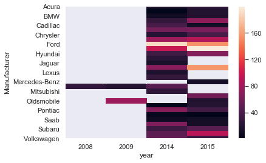

```python
sns.heatmap(carsales)
```

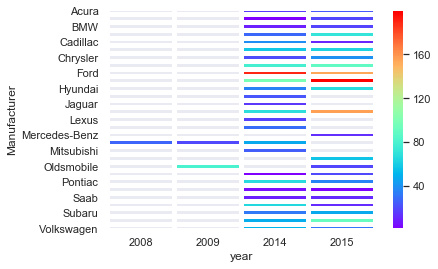

```python
sns.heatmap(carsales,cmap='rainbow',linecolor='white',linewidths=4)
```